# JHerrera_MPayne_RLagrois_week8casestudySec403

Joshua Herrera, Matthew Payne, Remy Lagrois

March 6, 2018

# Abstract

As the internet and the amount of data freely stored on it increases, it becomes important to be able to access this vast pool. Web scraping can be used to pull data from free online sources to be used in analysis. In this case study, we scraped text files from a website by using the XML library in R. After scraping, we clean the data and analyze it visually through the use of plots. All of this is performed upon the Cherry Blossom race data from 1999 to 2012, which is freely available online at www.CherryBlossom.org. We discovered that there has been a decline in the median age of runners over time, suggesting that the race is gaining popularity with younger people.

# Introduction

The objective of this case study is to determine a methodology to scrape data from a website to be used for visualization and analysis. The data we will be working with is free to access from the website and contains multiple variables such as place, running number, name, age, hometown, and time. The variable we will be focusing on is age, however, and we will be performing summary statistics on this variable and viewing how it changes over time.

# Methods

### Web Scraping

```r
extractResTable =
  #
  # Retrieve data from web site,
  # find the preformatted text,
  # and write lines to return as a character vector.
  #
  function(url = "http://www.cherryblossom.org/results/1999/cb99m.html",
           year = 1999, sex = "male", file = file)
  {
    doc = htmlParse(url, encoding = "utf-8")

    if (year == 2000) {
      # Get preformatted text from 4th font element
      # The top file is ill formed so the <pre> search doesn't work.
      ff = getNodeSet(doc, "//font")
      txt = xmlValue(ff[[4]])
      els = strsplit(txt, "\r\n")[[1]]
    }
    else if (year == 2009 & sex == "male") {
      # Get preformatted text from <div class="Section1"> element
      # Each line of results is in a <pre> element
      div1 = getNodeSet(doc, "//div[@class='Section1']")
      pres = getNodeSet(div1[[1]], "//pre")
      els = sapply(pres, xmlValue)
    }
    else if (year == 1999) {
      # Get preformatted text from <pre> elements
      pres = getNodeSet(doc, "//pre")
      txt = xmlValue(pres[[1]])
      els = strsplit(txt, "\n")[[1]]
    }
    else {
      # Get preformatted text from <pre> elements
      pres = getNodeSet(doc, "//pre")
      txt = xmlValue(pres[[1]])
      els = strsplit(txt, "\r\n")[[1]]
    }

    if (is.null(file)) return(els)
    # Write the lines as a text file.
    else
    writeLines(els, con = file)
    return(els)
  }
```

This extractor function was then run on the male and female URLs using mapply. The function is fed a list of URLs and years, returning a large list containing 14 elements, one for each year. The data is also downloaded to the local working directory /MenTxt or /WomenTxt, which is how we will input the data in our next section. After downloading the data, we double-check the data is correct and well formatted by appling the length function to each year’s table. We see that there are no errors in the data, and we are good to proceed.

```r
#You must have a MenTxt folder in your working directory!!
menTables = mapply(extractResTable, url = MenURLs, year = years, file=paste(getwd(),"/MenTxt/", years, ".txt", sep = ""))
names(menTables) = years
sapply(menTables, length)
```

```
## 1999 2000 2001 2002 2003 2004 2005 2006 2007 2008 2009 2010 2011 2012
## 3193 3019 3627 3727 3951 4164 4335 5245 5283 5913 6659 6919 7019 7201
```

```r
#You must have a WomenTxt folder in your working directory!!
womenTables = mapply(extractResTable, url = FemaleURLs, year = years, sex = rep("female", 14), file=paste(getwd(),"/WomenTxt/", years, ".txt", sep = ""))
names(womenTables) = years
sapply(womenTables, length)
```

```
## 1999 2000 2001 2002 2003 2004 2005 2006 2007 2008 2009 2010 2011 2012
## 3193 2169 2976 3338 3547 3907 4342 5445 5699 6405 8333 8863 9038 9738
```

### Data Cleaning

Now that we have scraped the race results files from the web into text files, we need to read them into R. We start by looking at the 2011 men’s results and immediately notice that there are some issues with the formatting. There is a header in the file that contains extraneous information and a row of equals signs between the header row and the data.

```r
els2011 = readLines("MenTxt/2011.txt")
els2011[1:10]
```

```
##  [1] ""
##  [2] "                 Credit Union Cherry Blossom Ten Mile Run"
##  [3] "                 Washington, DC     Sunday, April 3, 2011"
##  [4] ""
##  [5] "                           Official Male Results"
##  [6] ""
##  [7] "Place Div  /Tot   Num    Name                   Ag Hometown             5 Mile  Gun Tim Net Tim Pace  "
##  [8] "===== =========== ====== ====================== == ==================== ======= ======= ======= ===== "
##  [9] "    1     1/401        3 Lelisa Desisa          21 Ethiopia                       45:36   45:36  4:34 "
## [10] "    2     2/401       13 Allan Kiprono          21 Kenya                  23:08   45:41   45:41  4:35 "
```

We want to identify each of the elements in the file so that we can arrange them in the proper format. We can use regular expressions to identify the spacer row of equals signs and use that row to find the location of the header row and define the data below the spacer row as the body.

```r
els = readLines("MenTxt/2012.txt")
eqIndex = grep("^===", els)
spacerRow = els[eqIndex]
headerRow = els[eqIndex - 1]
body = els[ -(1:eqIndex) ]
headerRow
```

```
## [1] "Place Div  /Tot   Num    Name                   Ag Hometown             5 Mile  Time    Pace  "
```

We can see that we have located our header row, but the columns that each header represent do not have a character like a comma or tab separating them. We will need a function that can find the location of each header and map the columns based on that pattern. We can then use a function to extract the variables we are interested in for analysis.

```r
findColLocs = function(spacerRow) {
  spaceLocs = gregexpr(" ", spacerRow)[[1]]
  rowLength = nchar(spacerRow)

  if (substring(spacerRow, rowLength, rowLength) != " ")
    return( c(0, spaceLocs, rowLength + 1))
  else return(c(0, spaceLocs))
}
```

```r
selectCols = function(shortColNames, headerRow, searchLocs) {
  sapply(shortColNames, function(shortName, headerRow, searchLocs){
    startPos = regexpr(shortName, headerRow)[[1]]
    if (startPos == -1) return( c(NA, NA) )
    index = sum(startPos >= searchLocs)
    c(searchLocs[index] + 1, searchLocs[index + 1])
  }, headerRow = headerRow, searchLocs = searchLocs )
}
```

```r
extractVariables =
  function(file, varNames =c("name", "home", "ag", "gun",
                             "net", "time"))
  {

    # Find the index of the row with =s
    eqIndex = grep("^===", file)
    # Extract the two key rows and the data
    spacerRow = file[eqIndex]
    headerRow = tolower(file[ eqIndex - 1 ])
    body = file[ -(1 : eqIndex) ]
    # Remove footnotes and blank rows
    footnotes = grep("^[[:blank:]]*(\\*|\\#)", body)
    if ( length(footnotes) > 0 ) body = body[ -footnotes ]
    blanks = grep("^[[:blank:]]*$", body)
    if (length(blanks) > 0 ) body = body[ -blanks ]


    # Obtain the starting and ending positions of variables
    searchLocs = findColLocs(spacerRow)
    locCols = selectCols(varNames, headerRow, searchLocs)

    Values = mapply(substr, list(body), start = locCols[1, ],
                    stop = locCols[2, ])
    colnames(Values) = varNames

    return(Values)
  }
```

We read the race results for men and women from 1999-2012 into R and then create a matrix using the extractVariables function.

```r
wfilenames = paste("WomenTxt/", 1999:2012, ".txt", sep = "")
womenFiles = lapply(wfilenames, readLines)
names(womenFiles) = 1999:2012


mfilenames = paste("MenTxt/", 1999:2012, ".txt", sep = "")
menFiles = lapply(mfilenames, readLines)
names(menFiles) = 1999:2012
```

```r
menResMat = lapply(menFiles, extractVariables)
length(menResMat)
```

```
## [1] 14
```

The male race results matrix is complete, but the women’s results for 2001 lack a header. We can add the missing header from the men’s 2001 results to fix this problem and then our extract variables function will run without an error.

```r
# Fixes file without header
men2001 = readLines("MenTxt/2001.txt")
womenFiles[['2001']][2:3] = men2001[4:5]

womenResMat = lapply(womenFiles, extractVariables)
length(womenResMat)
```

```
## [1] 14
```

## Age

[figure not shown]

[output not shown]

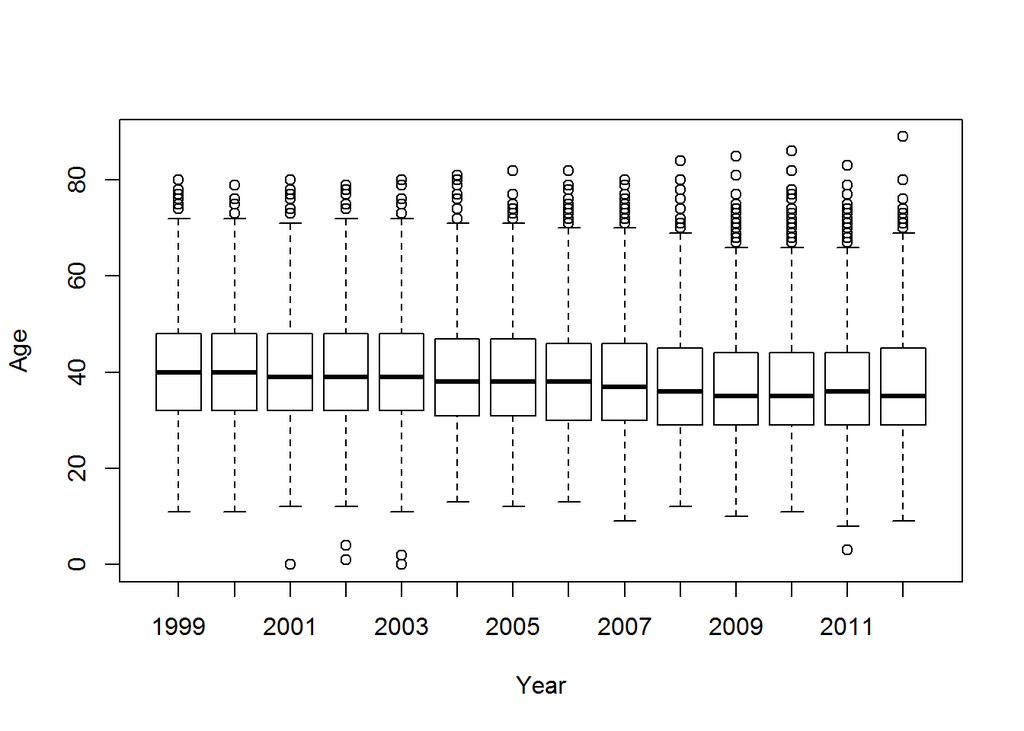

```r
#Men plot
age = sapply(menResMat,
             function(x) as.numeric(x[ , 'ag']))
boxplot(age, ylab = "Age", xlab = "Year")
```

```r
#count Na values
sapply(age, function(x) sum(is.na(x)))
```

```
## 1999 2000 2001 2002 2003 2004 2005 2006 2007 2008 2009 2010 2011 2012
##    1    0    0    2    0    0   10    0    3    1    0    4    0    1
```

The convert time function creates uniform times from the varying formats the runtimes were recorded in.

```r
convertTime = function(time) {
  timePieces = strsplit(time, ":")
  timePieces = sapply(timePieces, as.numeric)
  sapply(timePieces, function(x) {
    if (length(x) == 2) x[1] + x[2]/60
    else 60*x[1] + x[2] + x[3]/60
  })
}
```

The createDF function converts the times for each year, removes placeholder characters and blanks from each column, drops rows where the runner did not complete the race, and outputs a data frame.

```r
createDF = function(Res, year, sex)
{
  # Determine which time to use
  if ( !is.na(Res[1, 'net']) ) useTime = Res[ , 'net']
  else if ( !is.na(Res[1, 'gun']) ) useTime = Res[ , 'gun']
  else useTime = Res[ , 'time']

  # Remove # and * and blanks from time
  useTime = gsub("[#\\*[:blank:]]", "", useTime)
  runTime = convertTime(useTime[ useTime != "" ])

  # Drop rows with no time
  Res = Res[ useTime != "", ]

  Results = data.frame(year = rep(year, nrow(Res)),
                       sex = rep(sex, nrow(Res)),
                       name = Res[ , 'name'], home = Res[ , 'home'],
                       age = as.numeric(Res[, 'ag']),
                       runTime = runTime,
                       stringsAsFactors = FALSE)
  invisible(Results)
}
```

When the createDF function is used on the race results, there are thousands of NA values for the year 2006. On closer examination, the columns for that year are shifted and some adjustments are needed so that our previous functions execute for that year.

```r
separatorIdx = grep("^===", menFiles[["2006"]])
separatorRow = menFiles[['2006']][separatorIdx]
separatorRowX = paste(substring(separatorRow, 1, 63), " ",
                      substring(separatorRow, 65, nchar(separatorRow)),
                      sep = "")
menFiles[['2006']][separatorIdx] = separatorRowX

menResMat = sapply(menFiles, extractVariables)
menDF = mapply(createDF, menResMat, year = 1999:2012,
               sex = rep("M", 14), SIMPLIFY = FALSE)
separatorIdx = grep("^===", womenFiles[["2006"]])
separatorRow = womenFiles[['2006']][separatorIdx]
separatorRowX = paste(substring(separatorRow, 1, 63), " ",
                      substring(separatorRow, 65, nchar(separatorRow)),
                      sep = "")
womenFiles[['2006']][separatorIdx] = separatorRowX

womenResMat = sapply(womenFiles, extractVariables)
womenDF = mapply(createDF, womenResMat, year = 1999:2012,
               sex = rep("W", 14), SIMPLIFY = FALSE)
cbmen = do.call(rbind, menDF)
save(cbmen, file = "cbmen.rda")
dim(cbmen)
```

```
## [1] 70070     6
```

```r
summary(cbmen)
```

```
##       year          sex                name               home
##  Min.   :1999   Length:70070       Length:70070       Length:70070
##  1st Qu.:2004   Class :character   Class :character   Class :character
##  Median :2007   Mode  :character   Mode  :character   Mode  :character
##  Mean   :2007
##  3rd Qu.:2010
##  Max.   :2012
##
##       age           runTime
##  Min.   : 0.00   Min.   :  1.50
##  1st Qu.:30.00   1st Qu.: 77.23
##  Median :37.00   Median : 86.53
##  Mean   :38.61   Mean   : 87.48
##  3rd Qu.:46.00   3rd Qu.: 96.60
##  Max.   :89.00   Max.   :175.60
##  NA's   :22
```

```r
cbWomen = do.call(rbind, womenDF)
save(cbWomen, file = "cbWomen.rda")
dim(cbWomen)
```

```
## [1] 76806     6
```

```r
summary(cbWomen)
```

```
##       year          sex                name               home
##  Min.   :1999   Length:76806       Length:76806       Length:76806
##  1st Qu.:2005   Class :character   Class :character   Class :character
##  Median :2008   Mode  :character   Mode  :character   Mode  :character
##  Mean   :2007
##  3rd Qu.:2010
##  Max.   :2012
##
##       age           runTime
##  Min.   : 0.00   Min.   : 46.98
##  1st Qu.:27.00   1st Qu.: 87.93
##  Median :32.00   Median : 96.95
##  Mean   :34.09   Mean   : 97.59
##  3rd Qu.:40.00   3rd Qu.:106.52
##  Max.   :87.00   Max.   :177.52
##  NA's   :19
```

We now have data frames for the men’s and women’s race results from 1999-2012 to use for our analysis. Although a handful of NA values remain in the age column, they should not be significant to our record set of over 70 thousand runners.

### Data Exploration Analysis

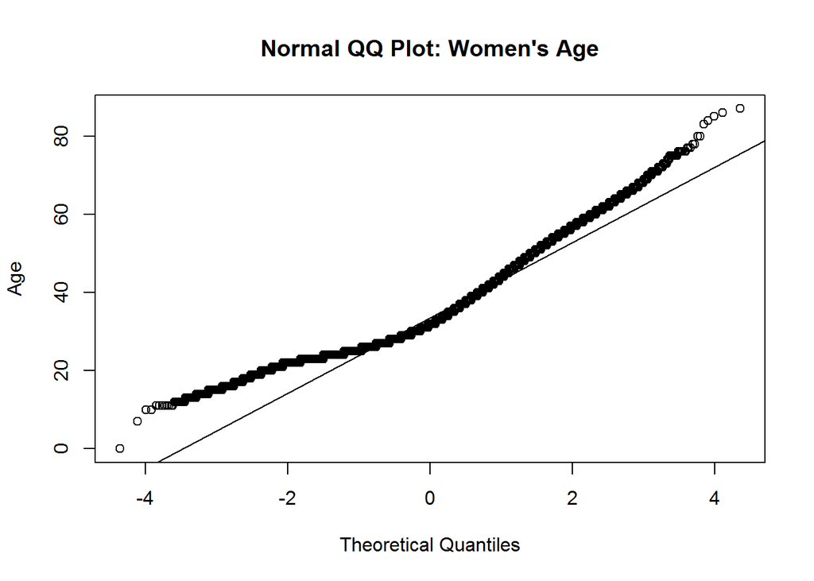

```r
#QQ Plots
qqnorm(cbWomen$age, main = "Normal QQ Plot: Women's Age", ylab = "Age")
qqline(cbWomen$age)
```

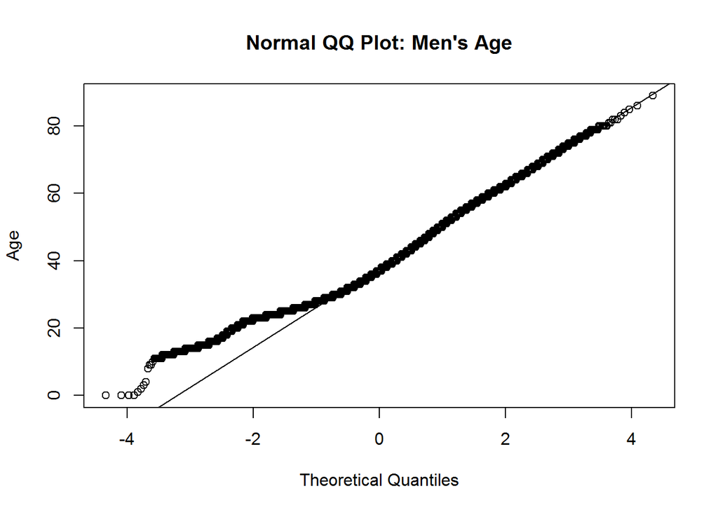

```r
qqnorm(cbmen$age, main = "Normal QQ Plot: Men's Age", ylab = "Age")
qqline(cbmen$age)
```

First, QQ plots were generated for both men and women’s ages plotted against a theortical normal distribution. Both plots show the distribution of age deviates from normal though the women do so more heavily. The women’s distribution appears to be right skewed meaning most runners tended to be young though there were older participants than would be expected under a normal distribution. The men’s QQ plot is closer to a normal age distribution with only a slight right skew.

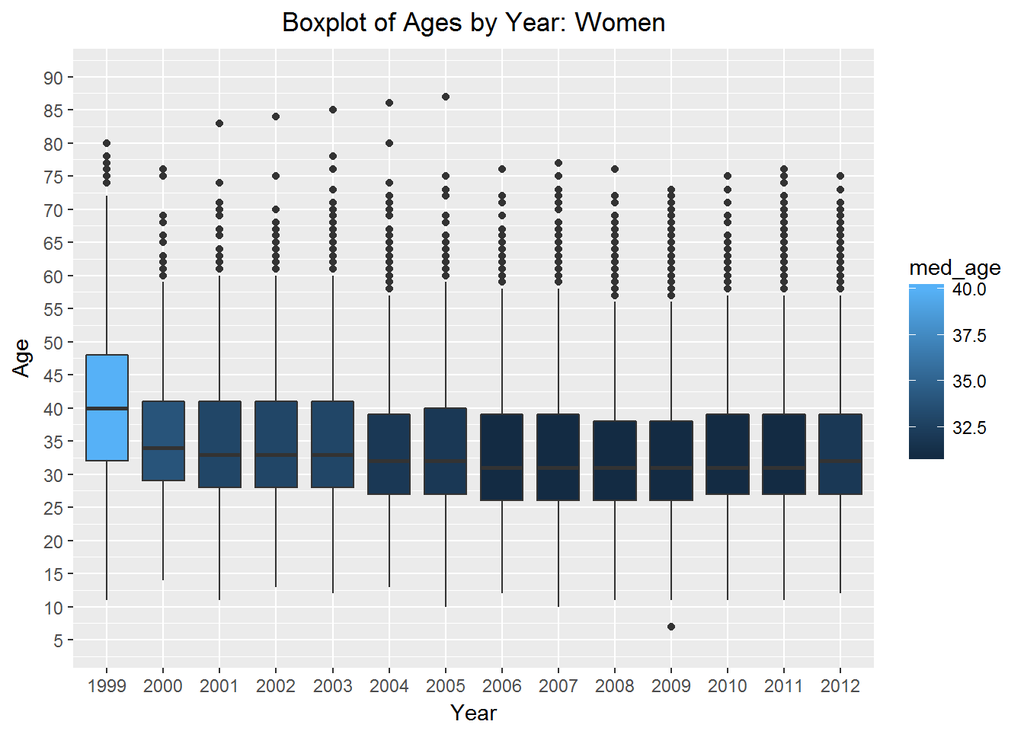

```r
#women colored by median
wBox2 <- ggplot(wData, aes(x=factor(year), y=age, fill=med_age)) + geom_boxplot()
wBox2 <- wBox2 + boxY + boxX + ggtitle("Boxplot of Ages by Year: Women") + theme(plot.title = element_text(hjust = 0.5))
wBox2
```